# SheltonR_Prediction_Assignment_Writeup-GBM

Robby Shelton

June 13, 2019

## The Problem and Approach to Finding a Solution

Data * Accelerometers on the belt, forearm, arm, and dumbell * Dumbell exercise in 10 repetitions for 6 participants Prediction * y = classe variable * x = any other variables * Model for Prediction of the way dumbell was done:  
“A” = done correctly “B” = throwing elbows to front “C” = lifting dumbell only half-way “D” = lowering dumbbell only half-way “E” = throwing hips to front

```r
library("readr")     # csv file importing
library("dplyr")     # working with data
library("tidyr")     # drop NA
library("ggplot2")   # grammer of graphics
library("ggthemes")  # graphics few() clean
library("caret")     # machine learning algorithms
library("e1071")     # in addtion to caret package, + svm
library("here")      # make working directory here - easier to map input/output directories
library("data.table")# %like% for parsing column names
library("gridExtra")
```

## Input data

```r
here()
pml_training <- read_csv("data/input/pml-training.csv")
pml_testing <- read_csv("data/input/pml-testing.csv")
```

Data has a lot of NAs. There are names, and a variety of data from each device. The variables can be characterized in the following groups. user, time Roll, pitch, yaw min, max, amplitude, total belt, arm, forearm, dumbell var, ave, std gyros, accel, magnet kurtosis, skewness

There isn’t a discrete #1-10 for repetitions for barbell exercises in each class. Ideally I would like to summarize the data by repetition. Dumbell lift #1, #2…#10, get a min, max, average, and for this to be used for training. But, the data provided are: raw_timestamp_part_1 raw_timestamp_part_2 cvtd_timestamp new_window num_window

Approach-Sludgehammer:  
Train on all data.

Approach-Component:  
Break down to each sensor by where sensor is utilized. Build each model, then combine these models together. Each sensor with data is important in regards to where it is located on the body. One type of data from one sensor may not be relevant to that same data collected on another sensor, to put simply, a vertical motion is important and most significant at the sensor worn at the hand and not the belt, where vertical motion would be hypothesized to be less.

Approach-Time-Spatial-relationships:  
Are these data cyclic, up-down, repeat, in the same set? If so, data in respect to time or barbell position in exercises has to also be accounted for.

Way to reduce data into the 10 repetitions? There are data for raw_timestamp_part_1 (very large number) raw_timestamp_part_2 (starts low, goes up, then back down again), cvtd_timestamp (static), new_window (yes, no), num_window (sequential), however, it was not immediately clear how to translate any of these variables to the begining and end of repetitions for the dumbbell movement in each cycle. Ideally it would be interesting to break this data set into 10 sets representing the 10 dumbbell repitions for each session.

## Data Summary, Exploration, and Creation of DataSet

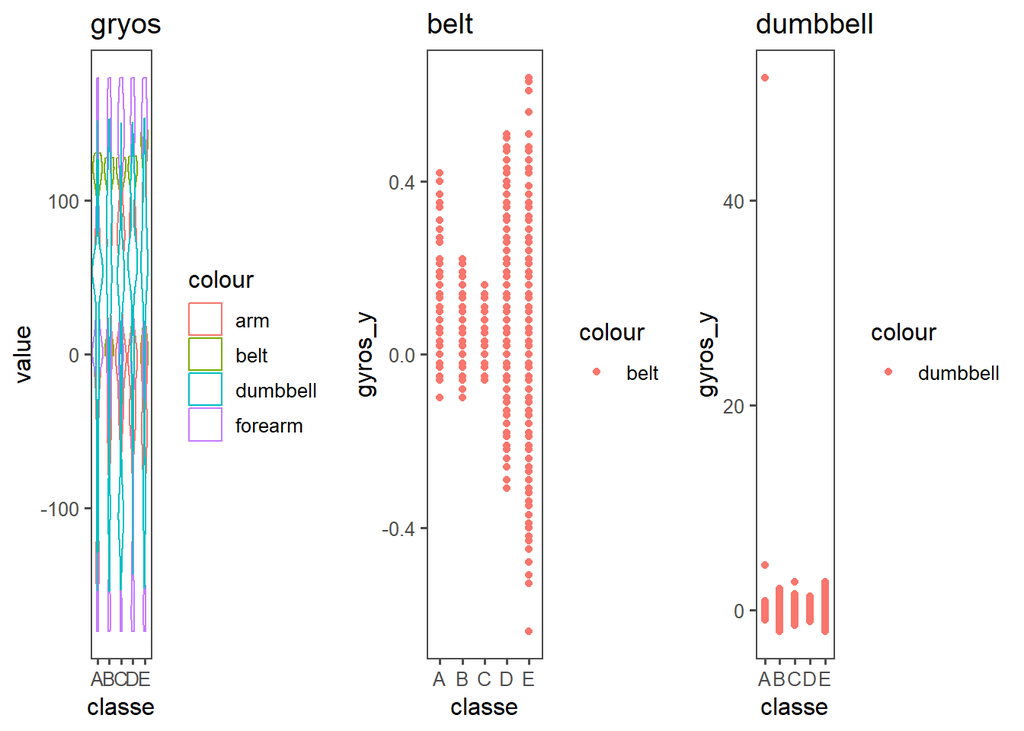

```r
# remove any columns with NA, treat preprocessing of both training and testing the same.
pml_training_clean <- pml_training[sapply(pml_training, function(pml_training) !any(is.na(pml_training)))]
pml_testing_clean <- pml_testing[sapply(pml_testing, function(pml_testing) !any(is.na(pml_testing)))]

#convert classe to factor
pml_training_clean$classe <-as.factor(pml_training_clean$classe)

# Sensor-worn-at-position:  dumbbell, forearm, arm, belt
# head(pml_training_clean[, colnames(pml_training_clean) %like% "belt"])
summary(pml_training_clean[, colnames(pml_training_clean) %like% "belt"])
pml_training_clean_belt <- data.frame(cbind(pml_training_clean[,"classe"],pml_training_clean[, colnames(pml_training_clean) %like% "belt"]))

# head(pml_training_clean[, colnames(pml_training_clean) %like% "forearm"])
summary(pml_training_clean[, colnames(pml_training_clean) %like% "forearm"])
pml_training_clean_forearm <- data.frame(cbind(pml_training_clean[,"classe"],pml_training_clean[, colnames(pml_training_clean) %like% "forearm"]))

# head(pml_training_clean[, colnames(pml_training_clean) %like% "_arm"])
summary(pml_training_clean[, colnames(pml_training_clean) %like% "_arm"])
pml_training_clean_arm <- data.frame(cbind(pml_training_clean[,"classe"],pml_training_clean[, colnames(pml_training_clean) %like% "_arm"]))

# head(pml_training_clean[, colnames(pml_training_clean) %like% "dumbbell"])
summary(pml_training_clean[, colnames(pml_training_clean) %like% "dumbbell"])
pml_training_clean_dumbbell <- data.frame(cbind(pml_training_clean[,"classe"],pml_training_clean[, colnames(pml_training_clean) %like% "dumbbell"]))

## Sensor output data:  Roll, pitch, yaw, gyros, accel
# Hypthesize that each classe will have patterns of readings from sensor that are characteristic of that classe, in other words, the way the dumbbell exercise is conducted.  There are patterns specific to each class, however, each value has a similar distribution for the parameters which is expected to be different for each.  Looking at the dataframe of these data confirm that these data are specific to the columns selected.

# summary(pml_training_clean[, colnames(pml_training_clean) %like% "roll"])
# summary(pml_training_clean[, colnames(pml_training_clean) %like% "pitch"])
# summary(pml_training_clean[, colnames(pml_training_clean) %like% "yaw"])
summary(pml_training_clean[, colnames(pml_training_clean) %like% "gyros"])
# summary(pml_training_clean[, colnames(pml_training_clean) %like% "accel"])

pml_training_clean_roll <- data.frame(cbind(pml_training_clean[,"classe"],pml_training_clean[, colnames(pml_training_clean) %like% "roll"]))
pml_training_clean_pitch <- data.frame(cbind(pml_training_clean[,"classe"],pml_training_clean[, colnames(pml_training_clean) %like% "pitch"]))
pml_training_clean_yaw <- data.frame(cbind(pml_training_clean[,"classe"],pml_training_clean[, colnames(pml_training_clean) %like% "yaw"]))
pml_training_clean_gyros <- data.frame(cbind(pml_training_clean[,"classe"],pml_training_clean[, colnames(pml_training_clean) %like% "gyros"]))
pml_training_clean_accel <- data.frame(cbind(pml_training_clean[,"classe"],pml_training_clean[, colnames(pml_training_clean) %like% "accel"]))

plot_gyros <- ggplot(pml_training_clean_gyros) + geom_violin(aes(x = pml_training_clean_roll$classe, y = pml_training_clean_roll$roll_belt, color = "belt")) + geom_violin(aes(x = pml_training_clean_roll$classe, y = pml_training_clean_roll$roll_arm, color = "arm")) + geom_violin(aes(x = pml_training_clean_roll$classe, y = pml_training_clean_roll$roll_forearm, color = "forearm")) + geom_violin(aes(x = pml_training_clean_roll$classe, y = pml_training_clean_roll$roll_dumbbell, color = "dumbbell")) + theme_few() + labs(x = "classe", y = "value", title = "gryos")

plot2 <- ggplot(pml_training_clean) + geom_point(aes(x=pml_training_clean$classe, y = pml_training_clean$gyros_belt_y, color = "belt")) + theme_few() + labs(x = "classe", y = "gyros_y", title = "belt")

plot3 <- ggplot(pml_training_clean) + geom_point(aes(x=pml_training_clean$classe, y = pml_training_clean$gyros_dumbbell_y, color = "dumbbell")) + theme_few() + labs(x = "classe", y = "gyros_y", title = "dumbbell")

# Using two of the locations, belt and dumbbell data, the gyro y variable is plotted for comparison:
plot_combined <- grid.arrange(plot_gyros, plot2, plot3, ncol = 3)
```

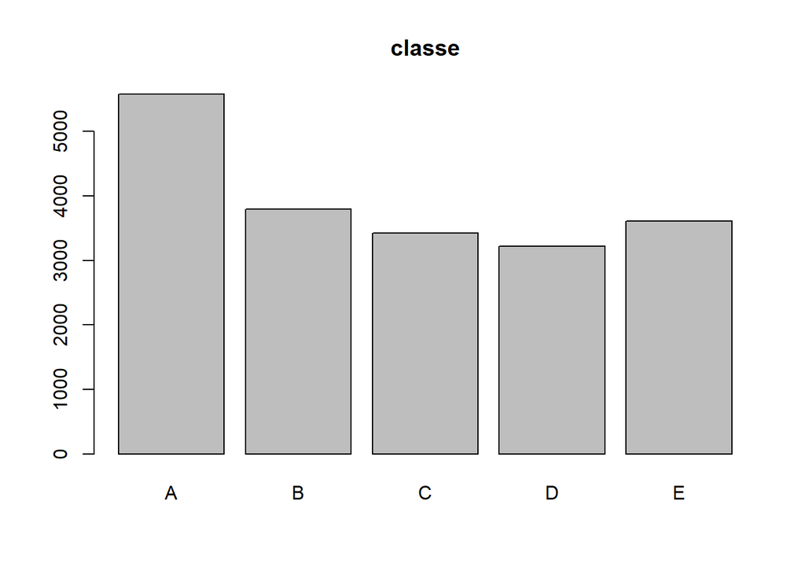

```r
## Are Classe balanced in the training dataset?
barplot(table(pml_training_clean$classe), main = "classe")
```

```r
percent_classe <- prop.table(table(pml_training_clean$classe)) *100
percent_classe

# Based on this these data may need to be undersampled for classe "A" to have a balanced dataset across classes.
```

```
   A        B        C        D        E
```

28.43747 19.35073 17.43961 16.38977 18.38243

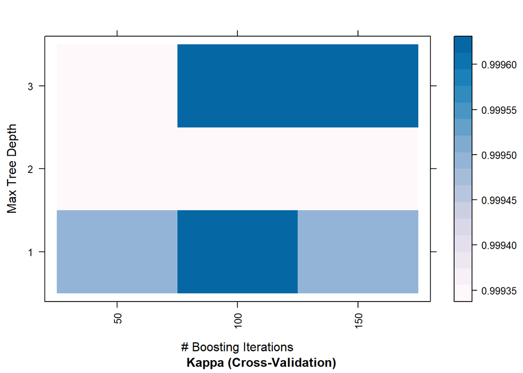

```r
memory.limit(16384) # use all memory
set.seed(3433) # For Reproducible Workflow, that these analysis may be repeated with same psuedo-random number generation for algorithm

inTrain = createDataPartition(pml_training_clean$classe, p = 0.50, list = FALSE)

# using same data partition as above, model for each sensor position separately.

pml_training_clean_belt <- data.frame(cbind(pml_training_clean[,"classe"],pml_training_clean[, colnames(pml_training_clean) %like% "belt"]))
pml_training_clean_belt <- cbind(pml_training_clean[3:7],pml_training_clean_belt) # taking out X1, name for each.

pml_training_clean_forearm <- data.frame(cbind(pml_training_clean[,"classe"],pml_training_clean[, colnames(pml_training_clean) %like% "forearm"]))
pml_training_clean_forearm <- cbind(pml_training_clean[3:7],pml_training_clean_forearm)

pml_training_clean_arm <- data.frame(cbind(pml_training_clean[,"classe"],pml_training_clean[, colnames(pml_training_clean) %like% "_arm"]))
pml_training_clean_arm <- cbind(pml_training_clean[3:7],pml_training_clean_arm)

pml_training_clean_dumbbell <- data.frame(cbind(pml_training_clean[,"classe"],pml_training_clean[, colnames(pml_training_clean) %like% "dumbbell"]))
pml_training_clean_dumbbell <- cbind(pml_training_clean[3:7],pml_training_clean_dumbbell)


fitControl <- trainControl(method = "cv", number = 10, summaryFunction = defaultSummary) # limit number = 10

# using same data inTrain to select partitioned data
training_belt = pml_training_clean_belt[ inTrain,]  #data for "time" and "window" already removed
testing_belt = pml_training_clean_belt[-inTrain,]  # I'm spliting my training set so that I get what the error values on the model before predicting the actual testing set of data.

modFit_gbm_belt <- train(classe ~., method = "gbm", trControl = fitControl, data = training_belt)
modFit_gbm_belt
df_testing_modFit_gbm_belt <- predict(modFit_gbm_belt, newdata = testing_belt)
confusionMatrix(df_testing_modFit_gbm_belt, testing_belt$classe)
# Accuracy : 0.9963

training_arm = pml_training_clean_arm[ inTrain,]
testing_arm = pml_training_clean_arm[-inTrain,]

modFit_gbm_arm <- train(classe ~., method = "gbm", trControl = fitControl, data = training_arm)
df_testing_modFit_gbm_arm <- predict(modFit_gbm_arm, newdata = testing_arm)
confusionMatrix(df_testing_modFit_gbm_arm, testing_arm$classe)
#   Accuracy : 0.9963


training_forearm = pml_training_clean_forearm[ inTrain,]
testing_forearm = pml_training_clean_forearm[-inTrain,]

modFit_gbm_forearm <- train(classe ~., method = "gbm", trControl = fitControl, data = training_forearm)
df_testing_modFit_gbm_forearm <- predict(modFit_gbm_forearm, newdata = testing_forearm)
confusionMatrix(df_testing_modFit_gbm_forearm, testing_forearm$classe)
# Accuracy : 0.9972


training_dumbbell = pml_training_clean_dumbbell[ inTrain,]
testing_dumbbell = pml_training_clean_dumbbell[-inTrain,]

modFit_gbm_dumbbell <- train(classe ~., method = "gbm", trControl = fitControl, data = training_dumbbell)
df_testing_modFit_gbm_dumbbell <- predict(modFit_gbm_dumbbell, newdata = testing_dumbbell)
confusionMatrix(df_testing_modFit_gbm_dumbbell, testing_dumbbell$classe)
#  Accuracy : 0.9977


# saving the big model for last since it takes a while to run.
pml_training_clean_all <- pml_training_clean[3:ncol(pml_training_clean)]

training = pml_training_clean[ inTrain,]
testing = pml_training_clean[-inTrain,]

modFit_gbm_all <- train(classe ~., method = "gbm", trControl = fitControl, data = training)
df_testing_modFit_gbm_all <- predict(modFit_gbm_all, newdata = testing)
confusionMatrix(df_testing_modFit_gbm_all, testing$classe)
#  Accuracy : 0.9998

# combine predictors together to see if better predictor and accuracy may be achieved.
pred1 <- predict(modFit_gbm_forearm, testing)
pred2 <- predict(modFit_gbm_arm, testing)
pred3 <- predict(modFit_gbm_belt, testing)
pred4 <- predict(modFit_gbm_dumbbell, testing)
pred5 <- predict(modFit_gbm_all, testing)

df_pred_gbm <- data.frame(pred1, pred2, pred3, pred4, pred5, classe = testing$classe)

combModFit_gbm <- train(classe ~., method="gbm", trControl = fitControl, data = df_pred_gbm)
df_testing_combModFit_gbm <- predict(combModFit_gbm, newdata = testing)
confusionMatrix(df_testing_combModFit_gbm, testing$classe)
# Accuracy : 0.9998

#  The combination of all data is the best model, and is similar accuracy to the combined model based on sensor location and overall model.
print(modFit_gbm_all$finalModel)
trellis.par.set(caretTheme())
plot(modFit_gbm_all, metric = "Kappa", plotType = "level",
     scales = list(x = list(rot = 90)))
```

**How cross-validation done** These data in training dataset were partitioned, 50% for training, and 50% for validation and determination of error for the models. Specifically, inTrain = createDataPartition(pml_training_clean$classe, p = 0.5, list = FALSE). Further validation was done with the predictive model as cross-validation is done to find the optimal tree during iterations.

```r
AccuracyResults <- modFit_gbm_all$results
OOSE <- 1- AccuracyResults$Accuracy[1]
print(paste("expected out of sample error, or generalization error =", OOSE))
```

[output not shown]

**Decisions** These data didn’t allow me to use glm, therefore gbm or random forrest were both models that are applicable.

Sensor position is important, and each would have unique patterns in data that correspond to the type of motion in that location. This is why I allocated the positions data separately and together in order to make a combined model that took advantage of each postions pattern of data as well as all together.

I was stuck on how ten repetitions could be pulled out of the data, such that a window of time for one replicate of dumbbell motion could be analyzed as a window of data, repeated ten times.

**Predict 20 different test cases**

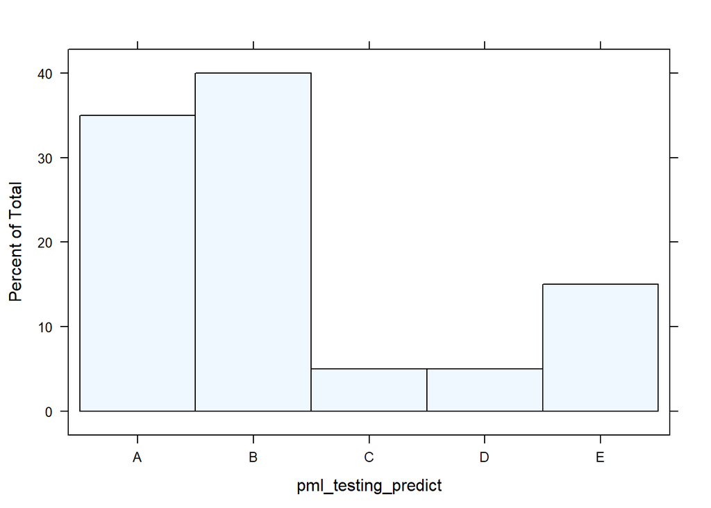

```r
pml_testing_clean <- pml_testing_clean[3:ncol(pml_testing_clean)]
pml_testing_predict <- predict(modFit_gbm_belt, newdata = pml_testing_clean)

histogram(pml_testing_predict)
```

[figure not shown]

```r
# Model used for predictions, most practical for study participant to use one fitness tracker in one location rather than 4 for practical use.
confusionMatrix(df_testing_modFit_gbm_belt, testing_belt$classe)

pml_testing_predict_comb <- predict(combModFit_gbm, newdata = pml_testing_clean)
histogram(pml_testing_predict_comb)
```

```r
model_predict <-modFit_gbm_belt
print(paste("1", predict(model_predict, newdata = pml_testing_clean[1,])))
print(paste("2", predict(model_predict, newdata = pml_testing_clean[2,])))
print(paste("3", predict(model_predict, newdata = pml_testing_clean[3,])))
print(paste("4", predict(model_predict, newdata = pml_testing_clean[4,])))
print(paste("5", predict(model_predict, newdata = pml_testing_clean[5,])))
print(paste("6", predict(model_predict, newdata = pml_testing_clean[6,])))
print(paste("7", predict(model_predict, newdata = pml_testing_clean[7,])))
print(paste("8", predict(model_predict, newdata = pml_testing_clean[8,])))
print(paste("9", predict(model_predict, newdata = pml_testing_clean[9,])))
print(paste("10", predict(model_predict, newdata = pml_testing_clean[10,])))
print(paste("11", predict(model_predict, newdata = pml_testing_clean[11,])))
print(paste("12", predict(model_predict, newdata = pml_testing_clean[12,])))
print(paste("13", predict(model_predict, newdata = pml_testing_clean[13,])))
print(paste("14", predict(model_predict, newdata = pml_testing_clean[14,])))
print(paste("15", predict(model_predict, newdata = pml_testing_clean[15,])))
print(paste("16", predict(model_predict, newdata = pml_testing_clean[16,])))
print(paste("17", predict(model_predict, newdata = pml_testing_clean[17,])))
print(paste("18", predict(model_predict, newdata = pml_testing_clean[18,])))
print(paste("19", predict(model_predict, newdata = pml_testing_clean[19,])))
print(paste("20", predict(model_predict, newdata = pml_testing_clean[20,])))
```

[output not shown]

**Citation** Citation Ugulino,W.; Cardador,D.; Vega,K.; Velloso,E.; Milidiu, R.; Fuks, H. WearableComputing: Accelerometers’ Data Classification of Body Posturesand Movements. Proceedings of 21st Brazilian Symposium onArtificial Intelligence. Advances in Artificial Intelligence - SBIA2012. In: Lecture Notes in Computer Science. , pp. 52-61. Curitiba,PR: Springer Berlin / Heidelberg, 2012. ISBN 978-3-642-34458-9. DOI:10.1007/978-3-642-34459-6_6.

**Data** http://web.archive.org/web/20161224072740/http:/groupware.les.inf.puc-rio.br/har: * training data https://d396qusza40orc.cloudfront.net/predmachlearn/pml-training.csv

- testing data https://d396qusza40orc.cloudfront.net/predmachlearn/pml-testing.csv